# Lab 9 | Jon Lee

Lab 9 | BINF 6310 | Spring 2020 | Jon Lee

Send your answers together with code to afodor@uncc.edu by Thursday, April 2nd.

1. This question uses data from this paper: https://science.sciencemag.org/content/347/6217/78 Variation in cancer risk among tissues can be explained by the number of stem cell divisions. Science 02 Jan 2015: Vol. 347, Issue 6217, pp. 78-81

(1A): Download the data from here examining the relationship between the number of cell divisions and cancer risk: https://fodorclasses.github.io/classes/stats2020/cancerRisk.txt

```r
#read in data file
cancerRisk <- read.table("cancerRisk.txt", sep = "\t", header = TRUE)
```

On a log10-log10 scale graph Lifetime_cancer_risk (on the y-axis) vs. CumulativeCellDivisions (on the x-axis). (This reproduces Fig. 1 from the paper). (You can read in the file with read.table(“cancerRisk.txt”, header=TRUE, sep=")

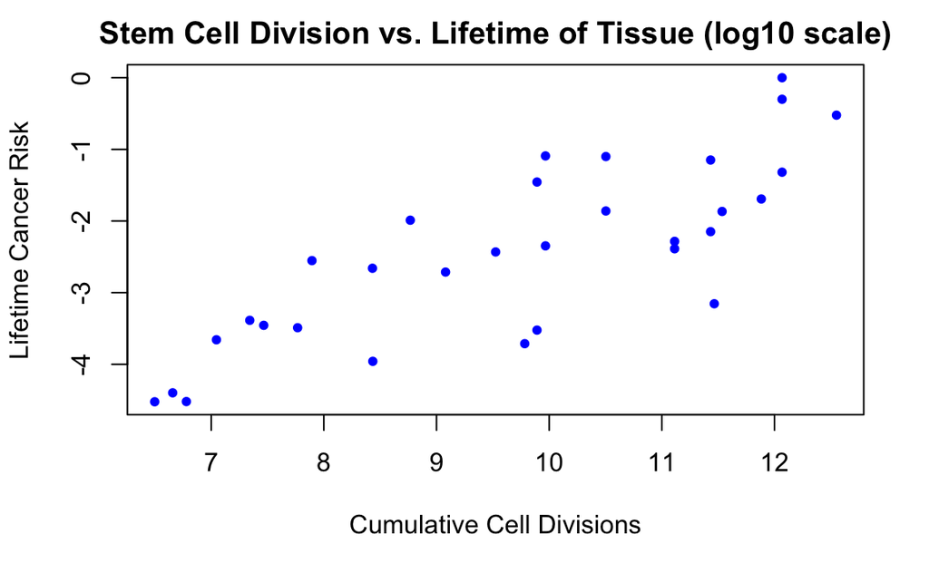

```r
#log10 transform data and assign to vectors
x <- log10(cancerRisk$CumulativeCellDivisions)
y <- log10(cancerRisk$Lifetime_cancer_risk)

#plot data
plot(x,y, pch = 20, col = "blue", xlab = "Cumulative Cell Divisions", ylab = "Lifetime Cancer Risk", main = "Stem Cell Division vs. Lifetime of Tissue (log10 scale)")
```

(1B): Using the lm function, fit a linear model with Lifetime_cancer_risk as the Y variable and CumulativeCellDivisions as the x-data. Add the regression line to the plot using the function abline(myLm) (where myLm is the linear model you created).

```r
#perform linear model and disply summary
cancerRiskLM <- lm(y ~ x)
summary(cancerRiskLM)
```

```
Call:
lm(formula = y ~ x)

Residuals:
     Min       1Q   Median       3Q      Max
-1.65115 -0.46564  0.06167  0.43180  1.21040

Coefficients:
            Estimate Std. Error t value Pr(>|t|)
(Intercept) -7.61081    0.72292 -10.528 2.03e-11 ***
x            0.53264    0.07317   7.279 5.12e-08 ***
---
Signif. codes:  0 ‘***’ 0.001 ‘**’ 0.01 ‘*’ 0.05 ‘.’ 0.1 ‘ ’ 1

Residual standard error: 0.7491 on 29 degrees of freedom
Multiple R-squared:  0.6463,    Adjusted R-squared:  0.6341
F-statistic: 52.99 on 1 and 29 DF,  p-value: 5.124e-08
```

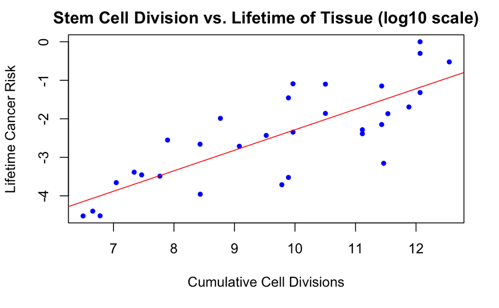

```r
#replot data with linear model line
plot(x,y, pch = 20, col = "blue", xlab = "Cumulative Cell Divisions", ylab = "Lifetime Cancer Risk", main = "Stem Cell Division vs. Lifetime of Tissue (log10 scale)")
abline(cancerRiskLM, col = "red")
```

(1C): What is the p-value for the null hypothesis that the slope of the regression between these two variables is zero? What is the r-squared value of the model?

Answer:

The p-value for the null that the slope is equal to 0 is 5.12e-08, and the r-squared value of the model is 0.6463. So therefore we reject the null that the slope is equal to 0 and the model is arelatively good fit to the data, but its not fantastic.

(1D): Are the assumptions of constant variance and normal distribution of the residues reasonable for this model? Justify your answer.

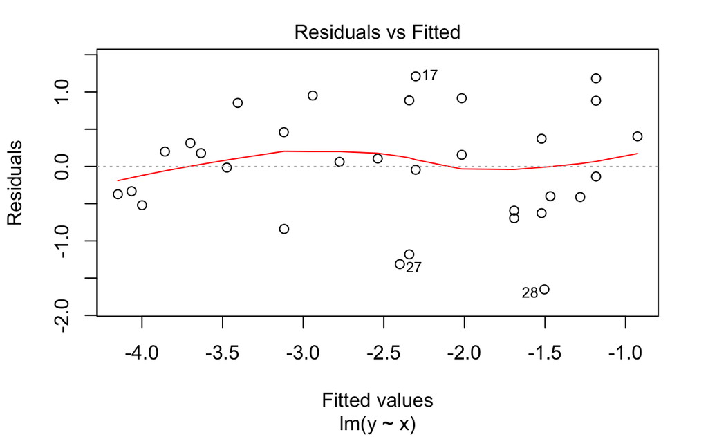

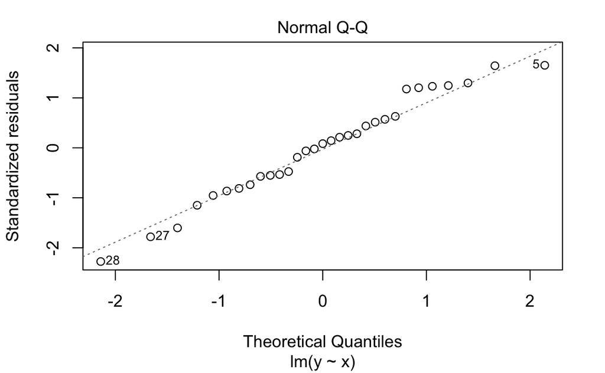

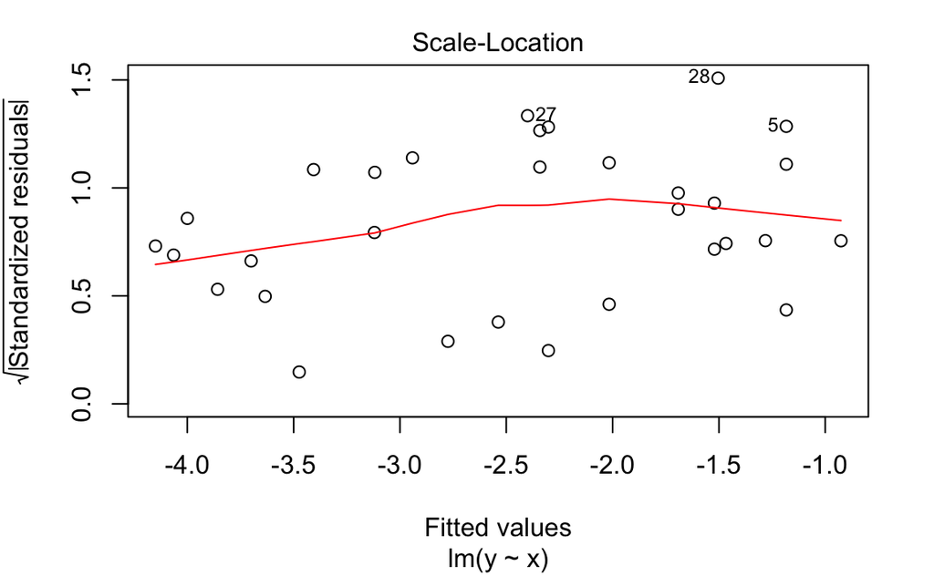

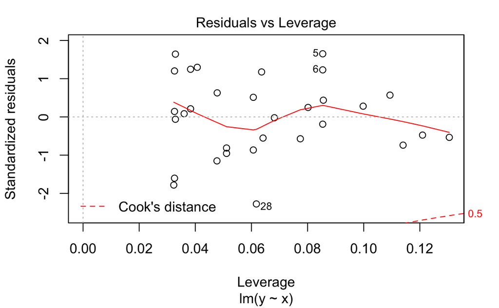

```r
#plot residual graphs for assumption constraints
plot(cancerRiskLM)
```

Answer:

The assumptions here would be reasonable, becauase when looking at the normality of the residuals, they follow the normality fairly well, and the outliers are not too extreme. Constance variance also hold fairly well when looking at the residuals too because they follow a constant line with outliers that are again not too extreme.